# a3_task3_alessandra_puig-santana

Alessandra Puig-Santana

10/28/2021

# Overview

Citation:

```r
knitr::opts_chunk$set(echo = TRUE)

library(tidyverse)
library(here)
library(janitor)
library(kableExtra)
library(lubridate)
```

Read in Data:

```r
urchins <- read_csv(here("data", "urchins.csv")) %>%
  clean_names() # Turns it to lower_case_snake
```

# Section 1

Comparing purple and red urchins.

#### Creating a smaller subset

```r
sub_urchins <- urchins %>%
  select(size, common_name)
```

#### Data visualization

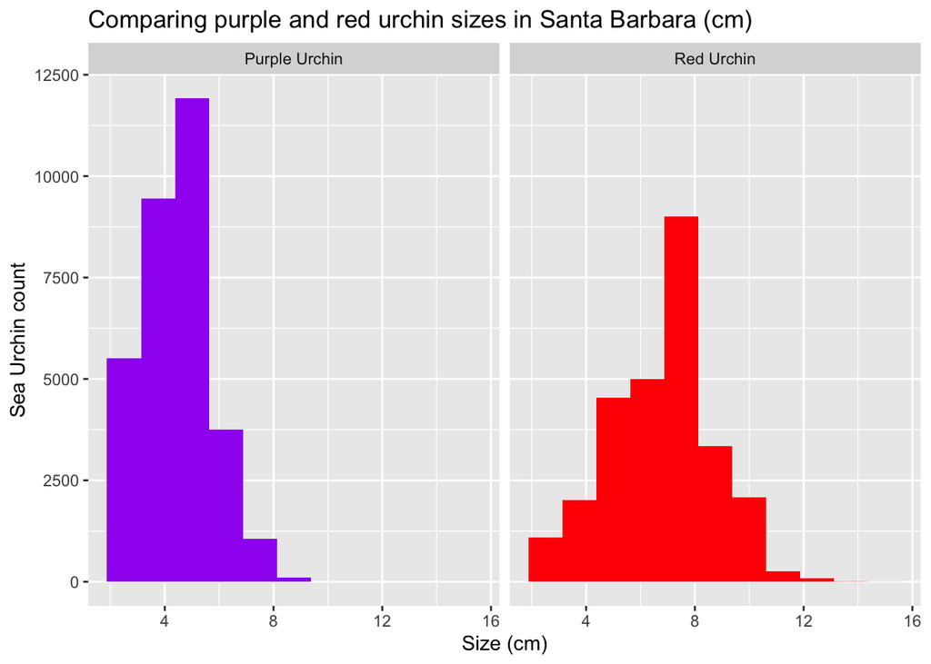

Figure 1: In this histogram, we are comparing the differences in sizes (cm) in purple and red urchins collected in Santa Barbara.

```r
ggplot(data = sub_urchins,
       aes(x = size)) +
  geom_histogram(bins = 11,
                 aes(fill = common_name),
                 show.legend = FALSE) +
  facet_wrap(~common_name) +
  scale_fill_manual(values = c("Purple Urchin" = "purple",
                               "Red Urchin" = "red")) +
  labs(title = "Comparing purple and red urchin sizes in Santa Barbara (cm)",
       x = "Size (cm)",
       y = "Sea Urchin count")
```

## Summary Statistics Table

Create a finalized summary table that contains the following statistics for purple and red urchins (still ignoring site as a variable, but including species as a grouping variable): mean, median, standard deviation, and sample size.

```r
urchins_stats <- sub_urchins %>%
  group_by(common_name) %>%
  summarize(mean_size = round(mean(size), 2),
            sd_size = round(sd(size), 2),
            median_size = round(median(size), 2),
            sample_size = n())

urchins_stats %>%
  kable(col.names = c("Species",
                      "Mean Size (cm)",
                      "Standard Deviation (cm)",
                      "Median (cm)",
                      "Sample Size"))
```

| Species | Mean Size (cm) | Standard Deviation (cm) | Median (cm) | Sample Size |
| --- | --- | --- | --- | --- |
| Purple Urchin | 4.47 | 1.18 | 4.5 | 31805 |
| Red Urchin | 6.78 | 1.89 | 7.0 | 27408 |

```r
urchins_stats
```

```
## # A tibble: 2 × 5
##   common_name   mean_size sd_size median_size sample_size
##   <chr>             <dbl>   <dbl>       <dbl>       <int>
## 1 Purple Urchin      4.47    1.18         4.5       31805
## 2 Red Urchin         6.78    1.89         7         27408
```

Description: - red urchin population has a larger distribution in sizes (cm) in comparison to the purple urchin population. - Difference in means (subtract the means) - The median is vastly different. - We can assume that our sample populations were collected from populations with different means.